# Question

Your goal is to make an animation (with 10 frames) of square pyramid spinning around a given axis. In 3D space, direction can be indicated with a unit vector $\vec{u}$:

$$\vec{u} = \begin{bmatrix}u_x \\ u_y \\
u_z \end{bmatrix}$$
A unit vector has a length of 1, so $u_x^2+u_y^2+u_z^2=1$.

In order to rotate points around the axis $\vec{u}$ by an angle $\theta$, we can use the [general 3D rotation matrix](https://en.wikipedia.org/wiki/Rotation_matrix#Rotation_matrix_from_axis_and_angle):

$$R = \begin{bmatrix}
\cos(\theta)+u_x^2(1-\cos(\theta)) &
u_xu_y(1-\cos(\theta))-u_z\sin(\theta) &
u_xu_z(1-\cos(\theta))+u_y\sin(\theta) \\
u_yu_x(1-\cos(\theta))+u_z\sin(\theta) &
\cos(\theta)+u_y^2(1-\cos(\theta)) &
u_yu_z(1-\cos(\theta))-u_x\sin(\theta) \\
u_zu_x(1-\cos(\theta))-u_y\sin(\theta) &
u_zu_y(1-\cos(\theta))+u_x\sin(\theta) &
\cos(\theta)+u_z^2(1-\cos(\theta)) \end{bmatrix}$$
Because our animation has 10 frames, the angle should be $\theta=\frac{2\pi}{10}$.

We will use the basic [orthographic projection](https://en.wikipedia.org/wiki/Orthographic_projection#Geometry) matrix below to flatten 3D points into a 2D plane:

$$P = \begin{bmatrix}1 & 0 & 0 \\
0 & 0 & 1\end{bmatrix}$$

The axis of rotation should be:

$$u_x=-0.3073873$$
$$u_y=0.3563153$$
$$u_z=0.8823562$$

Finish the code below to graph the animation.

```
n = 10 #The number of frames
X = matrix([[ 1,-1,-1, 1, 1, 0, 1,-1, 0,-1],
            [-1,-1, 1, 1,-1, 0, 1, 1, 0,-1],
            [-1,-1,-1,-1,-1, 1,-1,-1, 1,-1]])
P = matrix([[1,0,0],
            [0,0,1]])
R = ######### ENTER YOUR CODE HERE ##############
plots = []
for i in range(n):
    XP = P*R^i*X
    nextplot = line(XP.transpose(),xmin=-2,xmax=2,ymin=-2,ymax=2,axes=False,aspect_ratio=1)
    plots.append(nextplot)
a = animate(plots)
show(a)
```

Which animation matches?

## A

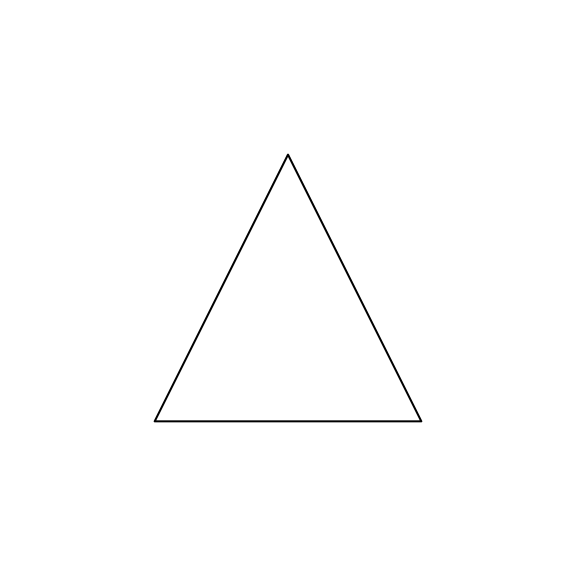

## B

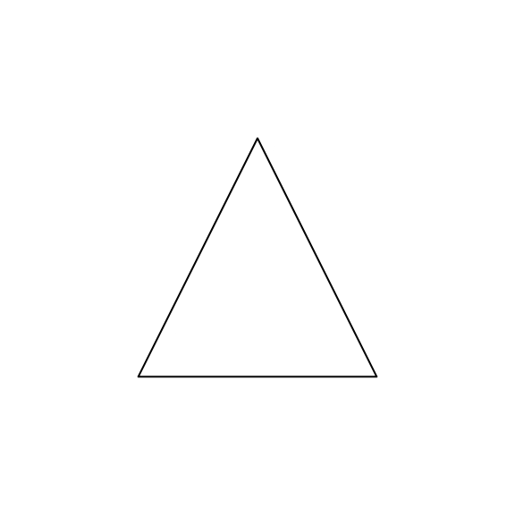

## C

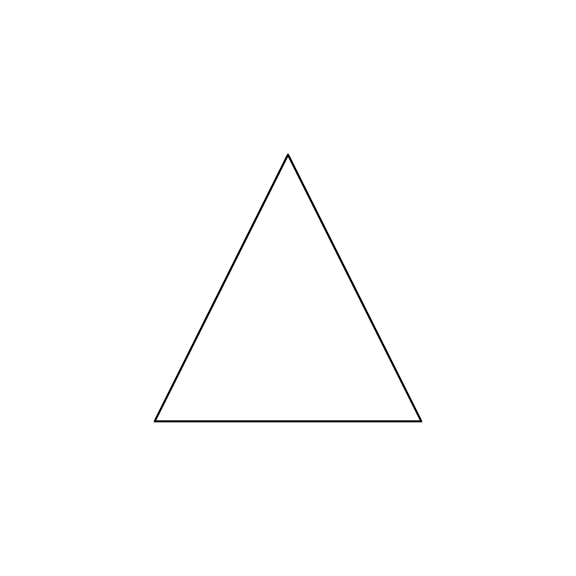

## D

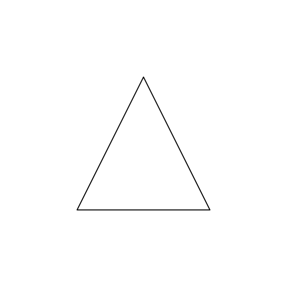

## Answerlist

- A
- B
- C
- D

# Solution

The answer is B.

[SageMath](https://sagecell.sagemath.org/)

```
n = 10 #The number of frames
X = matrix([[ 1,-1,-1, 1, 1, 0, 1,-1, 0,-1],
            [-1,-1, 1, 1,-1, 0, 1, 1, 0,-1],
            [-1,-1,-1,-1,-1, 1,-1,-1, 1,-1]])
P = matrix([[1,0,0],
            [0,0,1]])
R = matrix([[0.827062394682951,-0.539553719944344,0.157637491084841],[0.497718209254353,0.833264308438632,0.240722197686313],[-0.261236252227638,-0.120633227497689,0.957707285628312]])
plots = []
for i in range(n):
    XP = P*R^i*X
    nextplot = line(XP.transpose(),xmin=-2,xmax=2,ymin=-2,ymax=2,axes=False,aspect_ratio=1)
    plots.append(nextplot)
a = animate(plots)
show(a)
```

Instead of calculating each element of the rotation matrix (R), I would recommend putting in the formulas in terms of $u_x$, $u_y$, $u_z$, and $\theta$. You would need to define those variables before they were referenced:

```
ux = -0.3073873
uy = 0.3563153
uz = 0.8823562
th = 2*pi/n
```

And, heck, I’ll even write out the formulas for you.

```
r11 = cos(th)+ux^2*(1-cos(th))
r12 = ux*uy*(1-cos(th))-uz*sin(th)
r13 = ux*uz*(1-cos(th))+uy*sin(th)
r21 = uy*ux*(1-cos(th))+uz*sin(th)
r22 = cos(th)+uy^2*(1-cos(th))
r23 = uy*uz*(1-cos(th))-ux*sin(th)
r31 = uz*ux*(1-cos(th))-uy*sin(th)
r32 = uz*uy*(1-cos(th))+ux*sin(th)
r33 = cos(th)+uz^2*(1-cos(th))
R = matrix([[r11,r12,r13],
            [r21,r22,r23],
            [r31,r32,r33]])
```

# Meta-information

extype: schoice exsolution: 0100 exname: spinning_pyramid